# Actividad Semana 5: Datos misteriosos

## Técnicas Experimentales

### Facultad de Ciencias, UNAM

### Semestre 2021-1

- Hernández Mendoza Alicia Guadalupe
- Martínez Domínguez Ana Paula
- Ruiz Martínez Montserrat

## Campamento base

**1. ¿Qué información hay en el archivo a simple vista? (Encabezados, títulos, ubicaciones, ...) . Esta información adicional se conoce como metadatos y nos da información adicional de los datos de medición contenidos en el archivo. ¿Qué información te dan los metadatos de tu archivo?**

Es un artículo sobre radiación solar, la información fue recabada del 21 de junio hasta el 21 de septiembre del 2020, se encuentra disponible en la Red Oceánica de Canadá- Ocean Networks Canadá, de la Universidad de Victoria. El estudio fue realizado en la estación meteorológica de la bahía de Cambridge. Los datos se registraron a una Latitud norte de 69.114233 y a una Longitud este de -105.058967 a una profundidad de 0 metros. Los valores de Bandera y Cuenta son metadatos, es decir no son mediciones; los valores de Bandera nos dicen que tan óptima es la radiación.

**2. ¿Qué unidades de medición se reportan?**

Los datos corresponden a radiación solar que se mide en W/m^2 (vatios sobre metro cuadrado).

**3. ¿Estas unidades corresponden al Sistema Internacional de Unidades (SI)? Si no es así, ¿cuáles son las unidades equivalentes en el SI?**

Sí, corresponden al Sistema Internacional de Unidades.

```python
import pandas as pd
```

```python
pd.read_csv('datos/archivo03.csv', header=53, na_values=9999)
```

|  | Tiempo | Radiacion | Bandera | Cuenta |
| --- | --- | --- | --- | --- |
| 0 | 2020-06-21 00:30:00 | 57.948484 | 7 | 60 |
| 1 | 2020-06-21 01:30:00 | 74.972580 | 7 | 60 |
| 2 | 2020-06-21 02:30:00 | 29.037660 | 7 | 60 |
| 3 | 2020-06-21 03:30:00 | 28.617486 | 7 | 60 |
| 4 | 2020-06-21 04:30:00 | 25.466708 | 7 | 60 |
| ... | ... | ... | ... | ... |
| 2203 | 2020-09-20 19:30:00 | 116.889391 | 7 | 60 |
| 2204 | 2020-09-20 20:30:00 | 119.403856 | 7 | 60 |
| 2205 | 2020-09-20 21:30:00 | 106.621851 | 7 | 60 |
| 2206 | 2020-09-20 22:30:00 | 79.592921 | 7 | 60 |
| 2207 | 2020-09-20 23:30:00 | 38.500321 | 7 | 60 |

2208 rows × 4 columns

```python
data= pd.read_csv('datos/archivo03.csv', header=53, na_values= 9999)
```

```python
print(data)
```

```
                   Tiempo   Radiacion  Bandera  Cuenta
0     2020-06-21 00:30:00   57.948484        7      60
1     2020-06-21 01:30:00   74.972580        7      60
2     2020-06-21 02:30:00   29.037660        7      60
3     2020-06-21 03:30:00   28.617486        7      60
4     2020-06-21 04:30:00   25.466708        7      60
...                   ...         ...      ...     ...
2203  2020-09-20 19:30:00  116.889391        7      60
2204  2020-09-20 20:30:00  119.403856        7      60
2205  2020-09-20 21:30:00  106.621851        7      60
2206  2020-09-20 22:30:00   79.592921        7      60
2207  2020-09-20 23:30:00   38.500321        7      60

[2208 rows x 4 columns]
```

```python
print(data['Tiempo'])
```

```
0       2020-06-21 00:30:00
1       2020-06-21 01:30:00
2       2020-06-21 02:30:00
3       2020-06-21 03:30:00
4       2020-06-21 04:30:00
               ...
2203    2020-09-20 19:30:00
2204    2020-09-20 20:30:00
2205    2020-09-20 21:30:00
2206    2020-09-20 22:30:00
2207    2020-09-20 23:30:00
Name: Tiempo, Length: 2208, dtype: object
```

```python
print(data['Radiacion'])
```

```
0        57.948484
1        74.972580
2        29.037660
3        28.617486
4        25.466708
           ...
2203    116.889391
2204    119.403856
2205    106.621851
2206     79.592921
2207     38.500321
Name: Radiacion, Length: 2208, dtype: float64
```

## Sumidero de la incertidumbre

Grafiquen los datos.

1. La primera columna les da el tiempo en que se realizó la medición. Ésta es la variable independiente. Grafiquen las variables dependientes como función del tiempo. Recuerden etiquetar correctamente los ejes y poner unidades.
2. Elijan los parámetros adecuados para una visualización óptima de los datos. Para esto revisen:
   - El tamaño de los ejes,
   - que los marcadores y líneas sean visibles,
   - que el tamaño de la letra sea cómodo para leer,
   - que todos los ejes estén etiquetados correctamente,
   - que haya suficiente información para interpretar la gráfica.

```python
import matplotlib.pyplot as plt
```

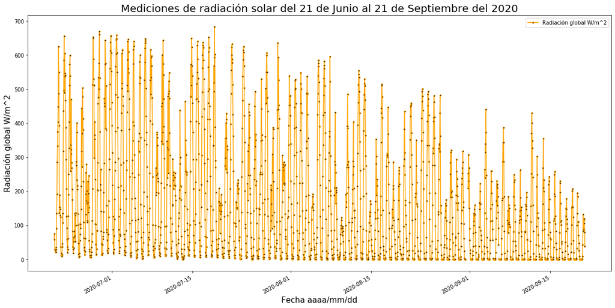

```python
fig = plt.figure(figsize=(20.0, 10.0))
ax = fig.add_subplot(1, 1, 1)

ax.plot(pd.to_datetime(data['Tiempo']), data['Radiacion'], color= 'orange', marker= '.', markerfacecolor= "k", label= 'Radiación global W/m^2')
ax.legend()

ax.set_ylabel('Radiación global W/m^2', size= 15)
ax.set_xlabel('Fecha aaaa/mm/dd', size= 15)
ax.set_title('Mediciones de radiación solar del 21 de Junio al 21 de Septiembre del 2020', size= 20)

fig.autofmt_xdate()
```

## Ascenso a la cima

Analicen los datos.

**1. Observen la gráfica que obtuvieron anteriormente y analicen lo siguiente.**

```
* ¿La variable dependiente es directamente proporcional al tiempo transcurrido, inversamente proporcional, o ninguna?
* ¿Observan algún ciclo?
```

**2. A partir de los metadatos, ¿pueden saber el lugar en donde se realizaron las mediciones? ¿Cuánto tiempo abarcan?**

Sí, las mediciones se realizaron en la estación meteorológica de la Bahía de Cambridge en el Ártico de Canadá. Los datos tomados son de las fechas del 21 de Junio al 21 de Septiembre del 2020.

**3. Analizando la dependencia entre las variables, las unidades de las mediciones, y el lugar de las mediciones ¿pueden pensar en algún fenómeno físico que se explique a partir de estos datos?**

Los datos fueron recabados en la temporada del verano boreal (hemisferio norte), que es cuando se alcanzan las mayores temperaturas, por ello podemos ver picos grandes de radiación, y conforme nos acercamos a septiembre los picos de radiación son más chicos. El eje de rotación de la Tierra y su inclinación son los causantes de que existan diferentes estaciones a lo largo del año, a pesar de encontrarse siempre a la misma distancia del Sol. Se puede tener verano en el hemisferio norte e invierno en el hemisferio sur al mismo tiempo, esto se debe a la inclinación de la Tierra, lo que ocasiona que el hemisferio Norte reciba más luz durante más tiempo en determinada época.

[figure not shown]

**4. Grafiquen porciones más pequeñas de sus datos. Por ejemplo solo un día, o unas horas. ¿Ven un comportamiento distinto?**

**5. Si hay más de una variable dependiente, comparen las dos variables dependientes (columnas 2 y 3 de sus datos). ¿Qué relación hay entre ellas? ¿Pueden explicar sus diferencias y similitudes con base en la información que tienen de cada columna? Si solo hay una variable dependiente (columna 2), ¿qué nos dice su comportamiento acerca del fenómeno físico medido?** ¿Qué pasa si comparas distintos periodos de tiempo dentro de la serie de datos?**

**6. Bono ¿Con qué instrumentos fueron realizadas estas mediciones? ¿Cómo funciona este aparato?**

Las mediciones se realizan utilizando un piranómetro (medición de la radiación global) y / o un pirheliómetro (medición de la radiación directa). Los piranómetros miden la densidad del flujo de radiación solar en una superficie plana con un campo de visión de 180°. Un método alternativo de medición de la radiación solar, que es menos preciso pero también menos caro, utiliza una grabadora de sol. Estas grabadoras de sol (también conocidos como grabadores Campbell-Stokes), miden el número de horas en el día durante el cual el sol está por encima de un cierto nivel (normalmente 200 mW/cm^2). Los datos recogidos de esta manera se pueden utilizar para determinar la insolación solar incluyendo varios factores de corrección y comparando el número de horas de sol medidas con aquellas basadas en los cálculos.

Medición de la Radiación Solar. Recuperado el 29 de octubre del 2020 de: https://www.pveducation.org/es/fotovoltaica/2-propiedades-de-la-luz-del-sol/medici%C3%B3n-de-la-radiaci%C3%B3n-solar

```
Graficamos desde 2020-06-21 00:30:00 hasta 2020-06-22 00:30:00
```

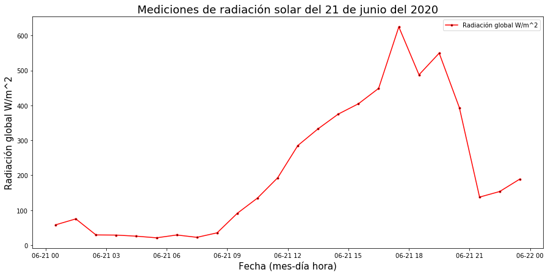

```python
fig = plt.figure(figsize=(15.0, 7.0))
ax = fig.add_subplot(1, 1, 1)

ax.plot(pd.to_datetime(data['Tiempo'][0:24]), data['Radiacion'][0:24], color= 'red', marker= '.', markerfacecolor= "k", label= 'Radiación global W/m^2')
ax.legend()

ax.set_ylabel('Radiación global W/m^2', size= 15)
ax.set_xlabel('Fecha (mes-día hora)', size= 15)
ax.set_title('Mediciones de radiación solar del 21 de junio del 2020', size= 18)

print('Graficamos desde', data['Tiempo'][0], 'hasta', data['Tiempo'][24])
```

```
Graficamos desde 2020-07-01 00:30:00 hasta 2020-07-02 00:30:00
```

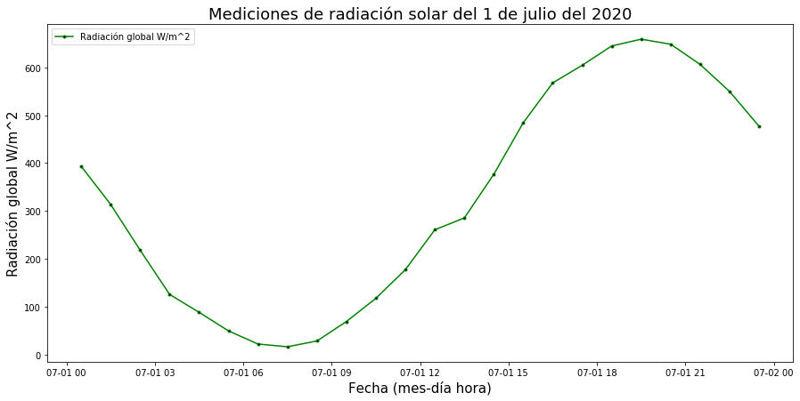

```python
fig = plt.figure(figsize=(15.0, 7.0))
ax = fig.add_subplot(1, 1, 1)

ax.plot(pd.to_datetime(data['Tiempo'][240:264]), data['Radiacion'][240:264], color= 'g', marker= '.', markerfacecolor= "k", label= 'Radiación global W/m^2')
ax.legend()

ax.set_ylabel('Radiación global W/m^2', size= 15)
ax.set_xlabel('Fecha (mes-día hora)', size= 15)
ax.set_title('Mediciones de radiación solar del 1 de julio del 2020', size= 18)

print('Graficamos desde', data['Tiempo'][240], 'hasta', data['Tiempo'][264])
```

```
Graficamos desde 2020-08-18 00:30:00 hasta 2020-08-19 00:30:00
```

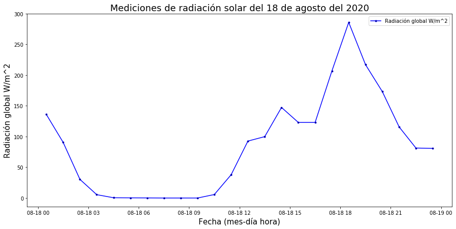

```python
fig = plt.figure(figsize=(15.0, 7.0))
ax = fig.add_subplot(1, 1, 1)

ax.plot(pd.to_datetime(data['Tiempo'][1392:1416]), data['Radiacion'][1392:1416], color= 'b', marker= '.', markerfacecolor= "k", label= 'Radiación global W/m^2')
ax.legend()

ax.set_ylabel('Radiación global W/m^2', size= 15)
ax.set_xlabel('Fecha (mes-día hora)', size= 15)
ax.set_title('Mediciones de radiación solar del 18 de agosto del 2020', size= 18)

print('Graficamos desde', data['Tiempo'][1392], 'hasta', data['Tiempo'][1416])
```

```
Graficamos desde 2020-09-20 00:30:00 hasta 2020-09-20 23:30:00
```

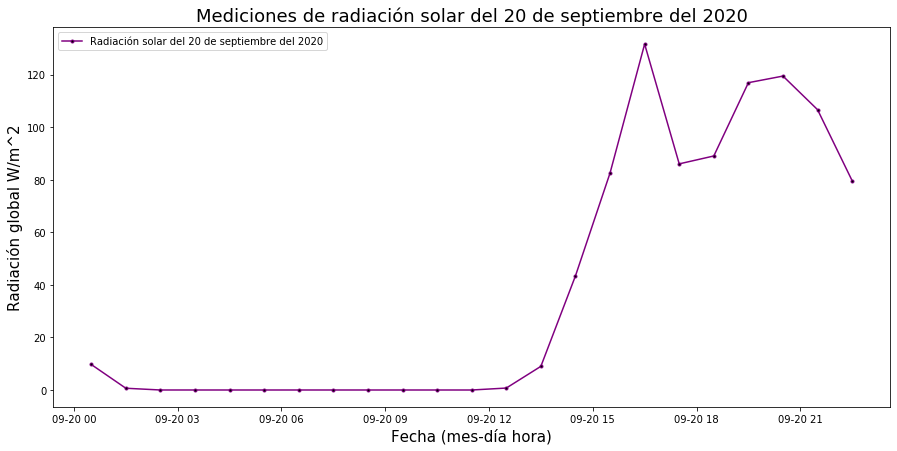

```python
fig = plt.figure(figsize=(15.0, 7.0))
ax = fig.add_subplot(1, 1, 1)

ax.plot(pd.to_datetime(data['Tiempo'][2184:2207]), data['Radiacion'][2184:2207], color= 'purple', marker= '.', markerfacecolor= "k", label= 'Radiación solar del 20 de septiembre del 2020')
ax.legend()

ax.set_ylabel('Radiación global W/m^2', size= 15)
ax.set_xlabel('Fecha (mes-día hora)', size= 15)
ax.set_title('Mediciones de radiación solar del 20 de septiembre del 2020', size= 18)

print('Graficamos desde', data['Tiempo'][2184], 'hasta', data['Tiempo'][2207])
```

**Conclusión:** Las variaciones de radiación solar van disminuyendo conforme pasan los meses durante la estación de verano en Canadá, esto lo pudimos relacionar con la incidencia de rayos solares según la órbita elíptica que realiza la Tierra en su movimiento de traslación.

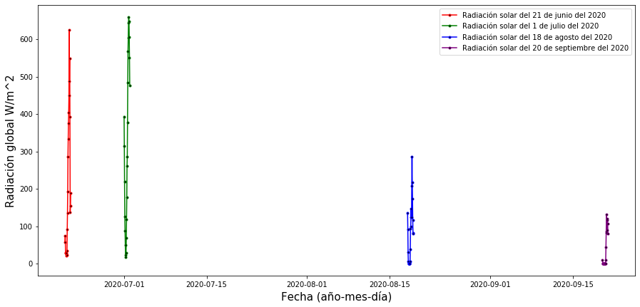

```python
fig = plt.figure(figsize=(15.0, 7.0))
ax = fig.add_subplot(1, 1, 1)

ax.plot(pd.to_datetime(data['Tiempo'][0:24]), data['Radiacion'][0:24], color= 'red', marker= '.', markerfacecolor= "k", label= 'Radiación solar del 21 de junio del 2020')
ax.legend()
ax.plot(pd.to_datetime(data['Tiempo'][240:264]), data['Radiacion'][240:264], color= 'g', marker= '.', markerfacecolor= "k", label= 'Radiación solar del 1 de julio del 2020')
ax.legend()
ax.plot(pd.to_datetime(data['Tiempo'][1392:1416]), data['Radiacion'][1392:1416], color= 'b', marker= '.', markerfacecolor= "k", label= 'Radiación solar del 18 de agosto del 2020')
ax.legend()
ax.plot(pd.to_datetime(data['Tiempo'][2184:2207]), data['Radiacion'][2184:2207], color= 'purple', marker= '.', markerfacecolor= "k", label= 'Radiación solar del 20 de septiembre del 2020')
ax.legend()

ax.set_ylabel('Radiación global W/m^2', size= 15)
ax.set_xlabel('Fecha (año-mes-día)', size= 15)
```